# Classification Project

Rezart Abazi & Aymir Aydinli

01/02/2021

$~$

$~$

## Abstract

Data for all loans issued through the 2007-2015, including the current loan status (Current, Late, Fully Paid, etc.) and latest payment information. The file containing loan data through the “present” contains complete loan data for all loans issued through the previous completed calendar quarter. Additional features include credit scores, number of finance inquiries, address including zip codes, and state, and collections, among others. This data is going to be used to test the prediction of the model regarding all the significant variables.

$~$

## Data Visualisation

We are dealing with a dataset which contains over 2 million observations, so it is classified as a large dataset and like one has a high probability of having a lot of data in it which is not of our interest. We first need to take a general look and try to find the NA and understand the distribution of all the data among the variable. By using a plot would be easier.

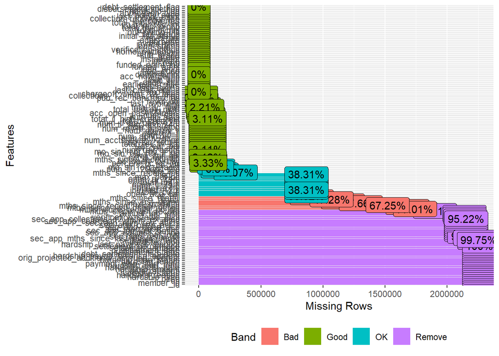

As we can see there are a lot of variables which have from 38.4% up to 99% of missing data. In this plot we see on the y-axis are the variables and the x-axis the number of missing values.  
The next step will be removing all the variables using a threshold.

$~$

## TARGET VARIABLE

| loan$loan_status | n |
| --- | --- |
| Charged Off | 261655 |
| Current | 919695 |
| Default | 31 |
| Does not meet the credit policy. Status:Charged Off | 761 |
| Does not meet the credit policy. Status:Fully Paid | 1988 |
| Fully Paid | 1041952 |
| In Grace Period | 8952 |
| Late (16-30 days) | 3737 |
| Late (31-120 days) | 21897 |

[output not shown]

9 rows

$~$

## Transforming “loan status” into a dichotomous variable

```r
#We merge the levels at call it "Suitable" for all of the clients who tend or are more likely to manage to pay their loan

loan$loan_status[loan$loan_status == "Does not meet the credit policy. Status:Fully Paid" |
                  loan$loan_status == "Fully Paid" |
                  loan$loan_status == "In Grace Period" |
                  loan$loan_status == "Late (16-30 days)"] <- "Suitable"



#We merge with the same criteria the levels which suits more to a client who is not going to be able to pay his loan.
loan$loan_status[loan$loan_status == "Charged Off" |
                   loan$loan_status == "Default" |
                   loan$loan_status == "Does not meet the credit policy. Status:Charged Off" |
                   loan$loan_status == "Late (31-120 days)"] <- "Default"
```

$~$

$~$

It is time to understand better the data with some descriptive statistics We did some combination between the variables which are more likely to be in positive or negative correlation to better understand the whole picture. For a better understanding let us start from the most obvious question: Which are the main reasons a person requires a loan? Thanks to “ggplot” package in R we can show you a graph will the most used loan purposes

$~$

Debt consolidation (debt consolidation refers to the act of taking out a new loan to pay off other liabilities and consumer debts, generally unsecured ones.) is in first place, credit card second, moving and home improvements.

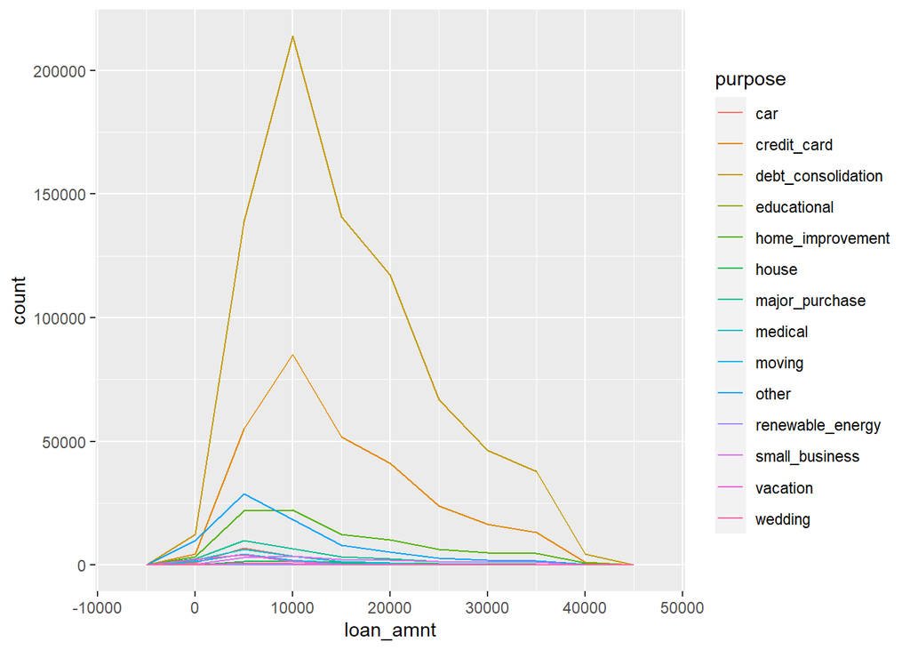

$~$

$~$

$~$

In this plot we have the representation of loan amount according to employer length. In our dataset the clients where from 1 year to 10 year + but for effect of space we choose only from the 7th to the 9th one. Interesting thing to notice about is the loan amount for the home ownership with label “ANY” gets smaller with increasing of years. Who is living in “RENT” is constant and “OTHER” in another group which increases

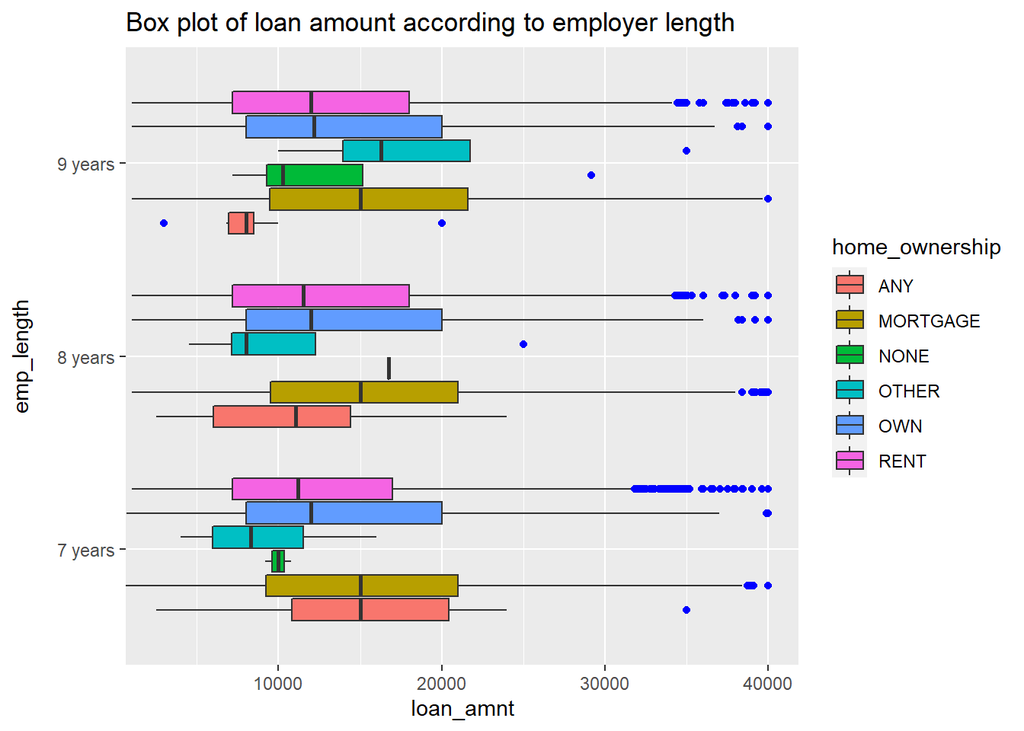

$~$

$~$

In order not to incur the over-fitting of the model, the dataset after all the data cleaning and removing the variables with missing values and the correlated variables consisted of 1.2 million observation and 22 variables. This dataset was divided into two subsets, a train consisting of 852367 observations and a test consisting of 365300 observations. The two sets were created by generating pseudo random numbers and extracting these lines from the initial set, thus forming the test set, and assigning the remaining statistical units to the train set.

$~$

## TRAIN AND TEST

```r
set.seed(987654321)

idx = sample(nrow(clean_loan), round(0.70*nrow(clean_loan)))

training_loan <- clean_loan[idx,]
test_loan <- clean_loan[-idx,]
```

$~$

This are all the numeric variables which will be evaluated by the model.

```
##  [1] "loan_amnt"            "funded_amnt"          "funded_amnt_inv"
##  [4] "term"                 "int_rate"             "installment"
##  [7] "grade"                "emp_length"           "home_ownership"
## [10] "annual_inc"           "verification_status"  "loan_status"
## [13] "purpose"              "dti"                  "inq_last_6mths"
## [16] "open_acc"             "revol_bal"            "revol_util"
## [19] "total_acc"            "total_pymnt"          "total_pymnt_inv"
## [22] "total_rec_prncp"      "total_rec_int"        "last_pymnt_amnt"
## [25] "acc_open_past_24mths" "bc_open_to_buy"       "bc_util"
## [28] "mort_acc"             "mths_since_recent_bc" "num_bc_sats"
## [31] "num_sats"             "percent_bc_gt_75"     "total_bal_ex_mort"
## [34] "total_bc_limit"
```

$~$

$~$

The correlation plot is shown after we removed the the variables which were correlated more 75% to avoid Multicollinearity. It happens when one predictor variable in a multiple regression model can be linearly predicted from the others with a high degree of accuracy. This can lead to skewed or misleading results.

$~$

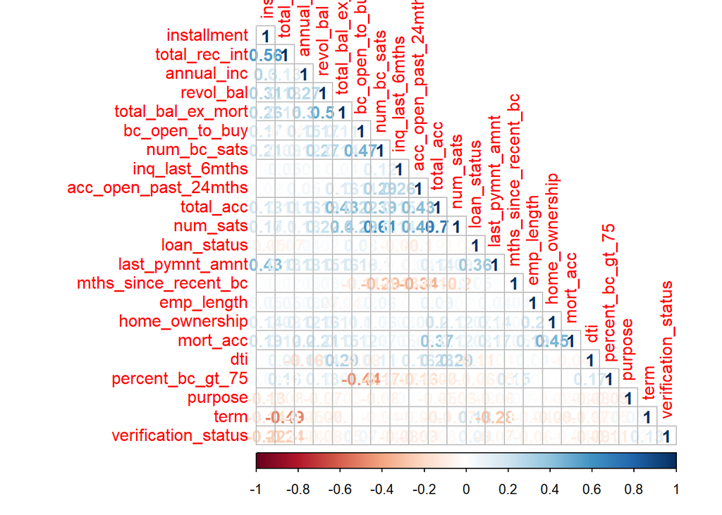

$~$

## MODEL ESTIMATION

```r
#this is my final model with all the variables significant after we removed the not significant
train_model <- glm(formula = loan_status ~ term + installment +
                     home_ownership + annual_inc + verification_status + purpose +
                     dti + inq_last_6mths + revol_bal + total_acc + total_rec_int +
                     last_pymnt_amnt + acc_open_past_24mths + bc_open_to_buy +
                     mort_acc + mths_since_recent_bc + num_bc_sats + num_sats +
                     percent_bc_gt_75 + total_bal_ex_mort, family = binomial,
                   data = training_loan)

#tab_model(train_model)
```

$~$

$~$

## Prediction Output

```
## Confusion Matrix and Statistics
##
##           Reference
## Prediction      0      1
##          0  42984  13043
##          1  33820 275453
##
##                Accuracy : 0.8717
##                  95% CI : (0.8706, 0.8728)
##     No Information Rate : 0.7898
##     P-Value [Acc > NIR] : < 2.2e-16
##
##                   Kappa : 0.5711
##
##  Mcnemar's Test P-Value : < 2.2e-16
##
##             Sensitivity : 0.5597
##             Specificity : 0.9548
##          Pos Pred Value : 0.7672
##          Neg Pred Value : 0.8906
##              Prevalence : 0.2102
##          Detection Rate : 0.1177
##    Detection Prevalence : 0.1534
##       Balanced Accuracy : 0.7572
##
##        'Positive' Class : 0
##
```

The classification model would be optimal if it maximizes both the sensitivity than specificity. This however is not possible: in fact, by raising the value of the specificity, the value of false positives decreases, but false negatives increase, which leads to one decreased sensitivity. It can therefore be observed that there is a trade-off between the two indices. The relationship between the above parameters can be represented through a line obtained reporting, in a system of Cartesian axes and for each possible cut-off value, the proportion of true positive in ordinate and the proportion of false positives in abscissa. he union of the points obtained reporting in the Cartesian plane each pair of Se and 1-Sp generates a broken, the ROC curve.

$~$

# ROC CURVE

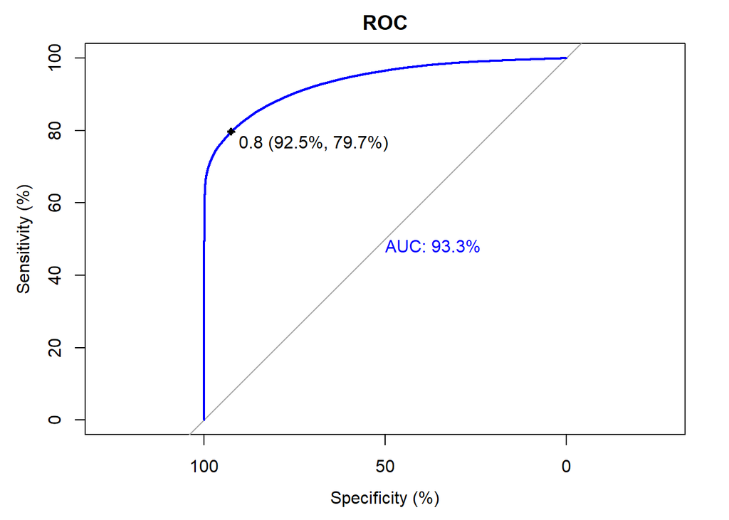

Sensitivity = TP/(TP+FN) ; expresses the proportion of True Positives compared to the total number of actual positives. Sensitivity is adversely affected by the share of false negatives

Specifity = TN/(FP+TN) ; expresses the proportion of True Negatives compared to the total number of actual negatives. There specificity is influenced by the share of false positives

$~$

$~$

## KNN Algorithm

$~$

For the model creation was used the method of repeated cross validation “repeateadcv” and for recent interations we used 10 and the repeats which is complete set of tools to repeat cross validation we used number three.

```
## Confusion Matrix and Statistics
##
##           Reference
## Prediction    0    1
##          0  224   77
##          1  544 2808
##
##                Accuracy : 0.83
##                  95% CI : (0.8174, 0.8421)
##     No Information Rate : 0.7898
##     P-Value [Acc > NIR] : 0.0000000005386
##
##                   Kappa : 0.3411
##
##  Mcnemar's Test P-Value : < 2.2e-16
##
##             Sensitivity : 0.29167
##             Specificity : 0.97331
##          Pos Pred Value : 0.74419
##          Neg Pred Value : 0.83771
##              Prevalence : 0.21024
##          Detection Rate : 0.06132
##    Detection Prevalence : 0.08240
##       Balanced Accuracy : 0.63249
##
##        'Positive' Class : 0
##
```

$~$

$~$

## DECISION TREE

```
## n= 8523
##
## node), split, n, loss, yval, (yprob)
##       * denotes terminal node
##
##   1) root 8523 1743 1 (0.204505456 0.795494544)
##     2) last_pymnt_amnt< 1231.04 3906 1719 1 (0.440092166 0.559907834)
##       4) term< 0.5 846  174 0 (0.794326241 0.205673759)
##         8) last_pymnt_amnt>=228.905 737  110 0 (0.850746269 0.149253731) *
##         9) last_pymnt_amnt< 228.905 109   45 1 (0.412844037 0.587155963) *
##       5) term>=0.5 3060 1047 1 (0.342156863 0.657843137)
##        10) last_pymnt_amnt>=47.745 2801 1035 1 (0.369510889 0.630489111)
##          20) acc_open_past_24mths>=4.5 1159  543 1 (0.468507334 0.531492666)
##            40) installment>=177.535 929  461 0 (0.503767492 0.496232508)
##              80) total_rec_int< 1198.04 247   74 0 (0.700404858 0.299595142) *
##              81) total_rec_int>=1198.04 682  295 1 (0.432551320 0.567448680)
##               162) installment>=800.305 96   33 0 (0.656250000 0.343750000) *
##               163) installment< 800.305 586  232 1 (0.395904437 0.604095563) *
##            41) installment< 177.535 230   75 1 (0.326086957 0.673913043) *
##          21) acc_open_past_24mths< 4.5 1642  492 1 (0.299634592 0.700365408) *
##        11) last_pymnt_amnt< 47.745 259   12 1 (0.046332046 0.953667954) *
##     3) last_pymnt_amnt>=1231.04 4617   24 1 (0.005198181 0.994801819) *
```

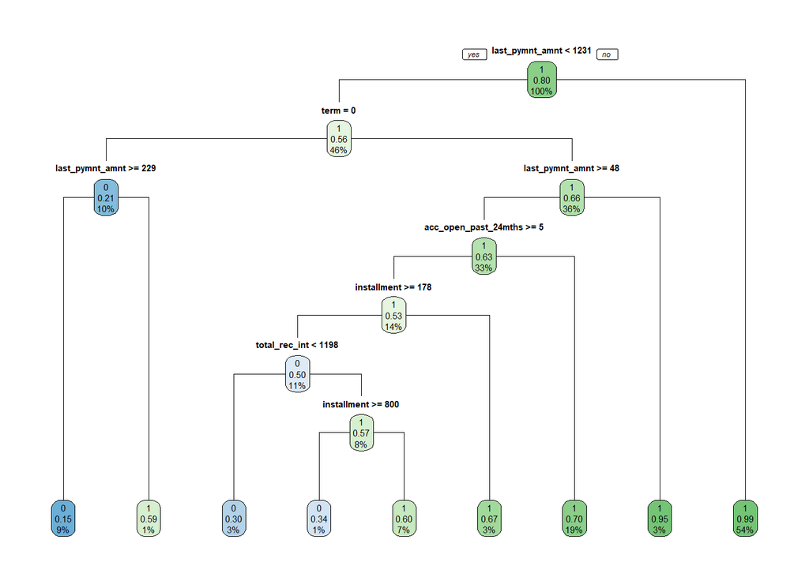

# STOPPING CRITERIA

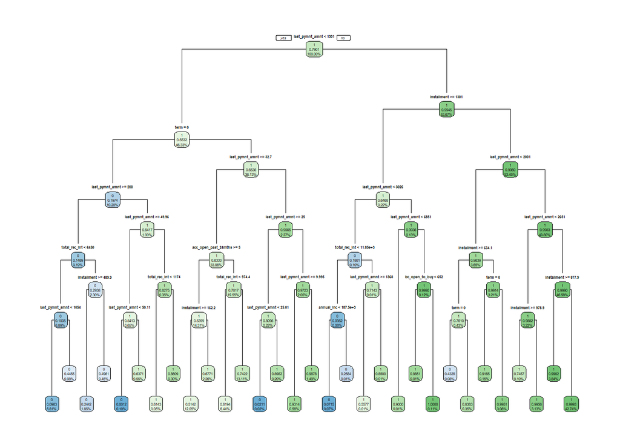